# Intro to Data Wrangling & Visualization

Assessment Quiz

Andrew Seaman

2025-Jan-25

## Q1

Use the mtcars dataset in R to compute the mean “Gross horsepower” of both automatic and manual transmission 1974 Motor Trend vehicles.

```r
# a.
mtcars %>%
  group_by(am) %>%
  summarise(
    "Transmission" = first(ifelse(am == 0, "Automatic", "Manual")),  # Convert numeric to text
    "Mean Gross Horsepower" = mean(hp, na.rm = TRUE),  # Ensure NA values are handled
    .groups = "drop"  # Prevent grouped output warning
  ) %>%
  pander()
```

| am | Transmission | Mean Gross Horsepower |
| --- | --- | --- |
| 0 | Automatic | 160.3 |
| 1 | Manual | 126.8 |

## Q2

Use the mtcars dataset in R to make a graph that allows you to see how the quarter mile time (qsec) of 1974 Motor Trend vehicles is effected by the number of carburetors (carb) in the vehicle.

Select the statement below that correctly describes this relationship.

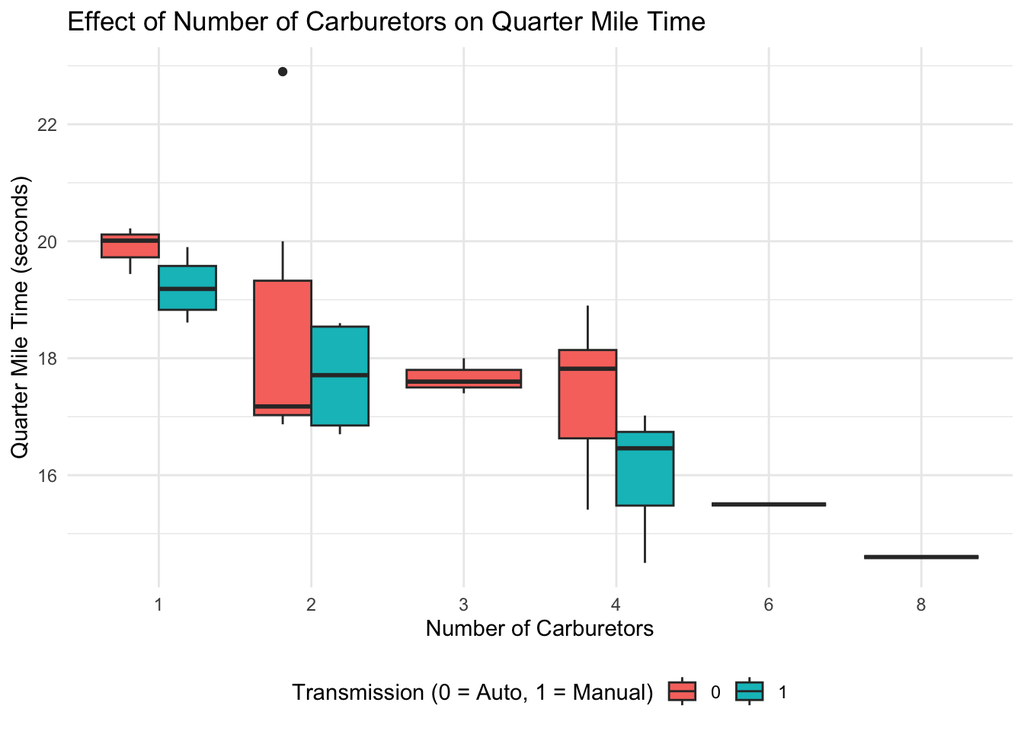

```r
# a.
mtcars %>%
  ggplot(aes(x = factor(carb), y = qsec, fill = factor(am))) +
  geom_boxplot(position = position_dodge(width = 0.75)) + # Dodge by transmission type
  labs(
    title = "Effect of Number of Carburetors on Quarter Mile Time",
    x = "Number of Carburetors",
    y = "Quarter Mile Time (seconds)",
    fill = "Transmission (0 = Auto, 1 = Manual)"
  ) +
  theme_minimal() +
  theme(
    legend.position = "bottom",
    axis.title = element_text(
      hjust =
    )
  )
```

## Q3

Run the following codes in R. Then select the statement that most appropriately interprets the resulting graph.

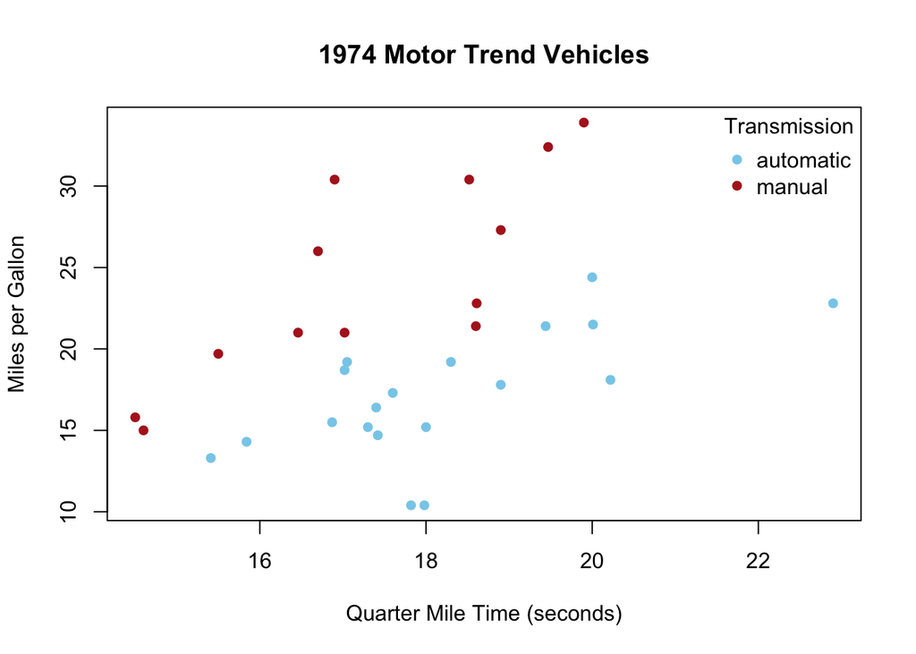

```r
# a.
palette(c("skyblue","firebrick"))

  plot(mpg ~ qsec, data=mtcars, col=as.factor(am), pch=16, xlab="Quarter Mile Time (seconds)", ylab="Miles per Gallon", main="1974 Motor Trend Vehicles")
  legend("topright", pch=16, legend=c("automatic","manual"), title="Transmission", bty='n', col=palette())
```

**Correct Answer:** The graph suggests that if you want a vehicle that gets really good gas mileage, you should go with a manual transmission that has a really slow quarter mile time.

**Explanation:** The graph produced by the code given shows gas mileage on the y-axis and quarter mile times on the x-axis. Also, as indicated by the legend, the color of the points is determined by whether the vehicle is automatic or manual transmission.

Since both transmission types show positive moderate correlations, we can conclude that higher quarter mile times (which means slower vehicles) correlate with higher gas mileages.